# Quick Guide to Geomorph

Emma Sherratt

10 February 2016

# 2. Generalized Procrustes Analysis

## Generalized Procrustes Analysis (`gpagen`)

Generalized Procrustes Analysis (GPA: Gower 1975; Rohlf and Slice 1990) is the primary means by which shape variables are obtained from landmark data (for a general overview of geometric morphometrics see Bookstein 1991; Rohlf and Marcus 1993; Adams et al. 2004; Mitteroecker and Gunz 2009; Zelditch et al. 2012; Adams et al. 2013). GPA translates all specimens to the origin, scales them to unit-centroid size, and optimally rotates them (using a least-squares criterion) until the coordinates of corresponding points align as closely as possible. The resulting aligned Procrustes coordinates represent the shape of each specimen, and are found in a curved space related to Kendall’s shape space (Kendall 1984). Typically, these are projected into a linear tangent space yielding Kendall’s tangent space coordinates (Dryden and Mardia 1993; Rohlf 1999), which are used for subsequent multivariate analyses. Additionally, any semilandmarks on curves and are slid along their tangent directions or tangent planes during the superimposition (see Bookstein 1997; Gunz et al. 2005). Presently, two implementations are possible: 1) the locations of semilandmarks can be optimized by minimizing the bending energy between the reference and target specimen (Bookstein 1997), or by minimizing the Procrustes distance between the two (Rohlf 2010).

**The first step in any geometric morphometric analysis is to perform a Procrustes superimposition of the raw coordinate data**

### Function:

`gpagen(A, curves = NULL, surfaces = NULL, PrinAxes = TRUE, max.iter = NULL, ProcD = TRUE, Proj = TRUE)`

### Arguments:

- *A* A 3D array (p x k x n) containing landmark coordinates for a set of specimens
- *curves* An optional matrix defining which landmarks should be treated as semilandmarks on boundary curves, and which landmarks specify the tangent directions for their sliding (see `define.sliders`)
- *surfaces* An optional vector defining which landmarks should be treated as semilandmarks on surfaces
- *PrinAxes* A logical value indicating whether or not to align the shape data by principal axes
- *max.iter* The maximum number of GPA iterations to perform before superimposition is halted. The final number of iterations could be larger than this, if curves or surface semilandmarks are involved
- *ProcD* A logical value indicating whether or not Procrustes distance should be used as the criterion for optimizing the positions of semilandmarks
- *Proj* A logical value indicating whether or not the aligned Procrustes residuals should be projected into tangent space

The function performs a Generalized Procrustes Analysis (GPA) on two-dimensional or three-dimensional landmark coordinates. The analysis can be performed on fixed landmark points, semilandmarks on curves, semilandmarks on surfaces, or any combination. To include semilandmarks on curves, one must specify a matrix defining which landmarks are to be treated as semilandmarks using the “curves=” option (this matrix can be made using `define.sliders`, see Vignette 5). Likewise, to include semilandmarks on surfaces, one must specify a vector listing which landmarks are to be treated as surface semilandmarks using the “surfaces=” option. The `ProcD=TRUE` option will slide the semilandmarks along their tangent directions using the Procrustes distance criterion, while `ProcD=FALSE` will slide the semilandmarks based on minimizing bending energy. The aligned Procrustes residuals can be projected into tangent space using the `Proj=TRUE` option. NOTE: Large datasets may exceed the memory limitations of R.

### Notes for geomorph 3.0

Compared to older versions of *geomorph*, users might notice subtle differences in Procrustes residuals when using semilandmarks (curves or surfaces). This difference is a result of using recursive updates of the consensus configuration with the sliding algorithms (minimized bending energy or Procrustes distances). (Previous versions used a single consensus through the sliding algorithms.) Shape differences using the recursive updates of the consensus configuration should be highly correlated with shape differences using a single consensus during the sliding algorithm, but rotational “flutter” can be expected. This should have no qualitative effect on inferential analyses using Procrustes residuals.

#### Using `plot`, `print`/`summary` on a gpagen object

The generic functions, `print`/`summary`, and `plot` all work with `gpagen`. The generic function, `plot` calls `plotAllSpecimens` and plots the aligned landmarks of all specimens with the mean. `print`/`summary` provide details of the GPA, including how many fixed and sliding semilandmarks are in the dataset, as well as how many GPA iterations it took to converge. Use `attributes` to see the elements contained in the returned list from `gpagen`.

### Procrustes Superimposition of Fixed Landmarks only

As an example, we will use the 2D landmarks of the salamander head data set saved within *geomorph*.

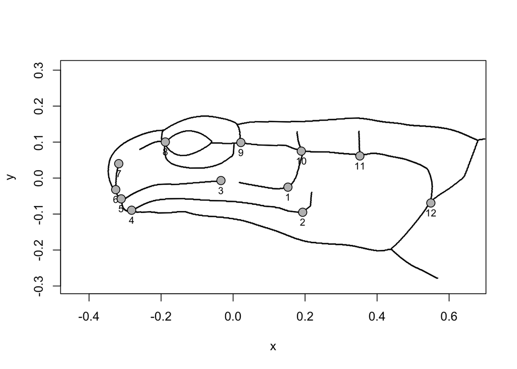

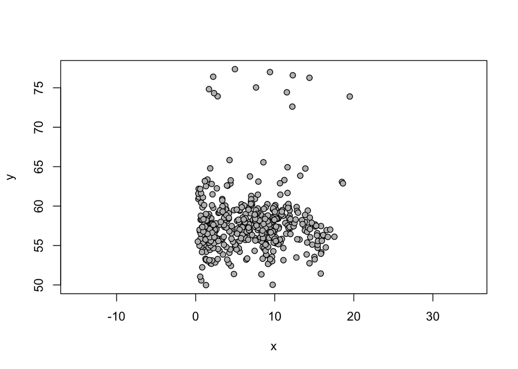

```r
data(plethodon) ## Load the data
## See that all the specimens are in different coordinate systems
plotAllSpecimens(plethodon$land, mean=FALSE)
```

Since all of the specimens were digitized from different images, when we plot the raw data we see the specimens are all if different coordinate systems and thus are all over the place.

To perform GPA-alignment

```r
plethodon.gpa <- gpagen(plethodon$land)
summary(plethodon.gpa)
```

```
Call:
gpagen(A = plethodon$land)



Generalized Procrustes Analysis
with Partial Procrustes Superimposition

12 fixed landmarks
0 semilandmarks (sliders)
2-dimensional landmarks
2 GPA iterations to converge


Consensus (mean) Configuration

                X            Y
 [1,]  0.15233235 -0.025236626
 [2,]  0.19328978 -0.095041326
 [3,] -0.03370053 -0.006929886
 [4,] -0.28182427 -0.089370884
 [5,] -0.31072667 -0.057833073
 [6,] -0.32600020 -0.032082163
 [7,] -0.31757271  0.040056683
 [8,] -0.18824427  0.100347120
 [9,]  0.02159274  0.098853350
[10,]  0.18946790  0.074940129
[11,]  0.35213100  0.061515224
[12,]  0.54925486 -0.069218549
```

Function returns a list containing the shape coordinates and centroid sizes:

```r
plethodon.gpa$coords ## a 3D array of Procrustes coordinates
plethodon.gpa$Csize ## a vector of centroid sizes
```

Other important information about the GPA is stored in the `plethodon.gpa` list. Use `attributes` to see, including: *iter* The number of GPA iterations until convergence was found (or GPA halted); *points.VCV Variance-covariance matrix among landmark coordinates;* points.var* Variances of landmark points; *consnsus* The consensus (mean) configuration; akin to using `mshape()`; *data* Data frame with an n x (pk) matrix of Procrustes residuals and centroid size; *Q* Final convergence criterion value; *slide.method* Method used to slide semilandmarks.

Stored in the example dataset `plethodon` are the wireframe links to aid visualisations. The function `plotAllSpecimens` plots landmark coordinates for a set of specimens:

```r
  plotAllSpecimens(plethodon.gpa$coords,links=plethodon$links)
```

To view the options for this function

```r
  ?plotAllSpecimens
```

### Procrustes Superimposition of datasets containing semilandmarks along a curve

The first example contained landmarks that are fixed, representing homologous points on the object. Oftentimes, researchers need to also use semilandmarks, which are points on a geometric feature (curve, edge, surface) defined mathematically in terms of its position on the feature (most commonly equally spaced). Semilandmarks provide information about curvature, and should be used alongside fixed landmarks.

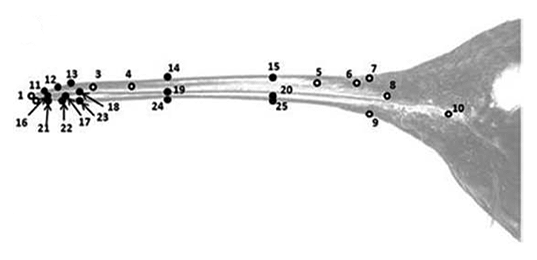

The `hummingbird` dataset, from Berns & Adams 2010, contains fixed landmarks (open circles) and semilandmarks (closed circles) that define the curvature of the beak. When semilandmarks are included in the dataset, a few extra parameters should be specified in the `gpagen` function.

First a curve sliding matrix should be made, to tell the function which landmarks are semilandmarks and how they will slide during the superimposition.

```r
  data(hummingbirds)
  hummingbirds$curvepts ## an example curve sliding matrix
        before slide after
 [1,]      1    11    12
 [2,]     11    12    13
 [3,]     13    14    15
 [4,]      7    15    14
 [5,]     12    13    14
 [6,]      1    16    17
 [7,]     16    17    18
 [8,]     17    18    19
 [9,]     18    19    20
[10,]     10    20    19
[11,]      2    21    22
[12,]     21    22    23
[13,]     22    23    24
[14,]     23    24    25
[15,]      8    25    24
```

The landmarks listed in the middle column are the semilandmarks.

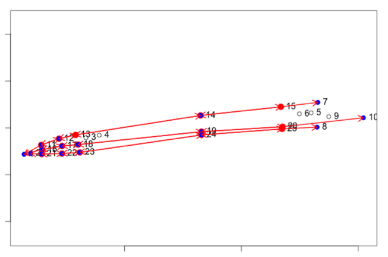

This image is a visual version of the matrix, made using the interactive function `define.sliders` (discussed later).

This curve sliding matrix is used in the `gpagen` option `curves`. There are two options for how the semilandmrks will slide, using Procrustes distance or bending energy:

```r
A <- gpagen(hummingbirds$land,
            curves=hummingbirds$curvepts,
            ProcD=TRUE) ## Using Procrustes Distance for sliding
B <- gpagen(hummingbirds$land,
            curves=hummingbirds$curvepts,
            ProcD=FALSE) ## Using bending energy for sliding
```

For more information of how these two methods differ, and when to use which, see Gunz and Mitteroecker 2013 (Hystrix, http://www.italian-journal-of-mammalogy.it/article/view/6292).

### Procrustes Superimposition of datasets containing semilandmarks over a 3D surface

As stated above, semilandmarks can also be points on a geometric feature such as a 3D surface. These data can be collected using the `buildtemplate` and `digitsurface` functions in *geomorph*.

The example data we shall now use is `scallops`. The first specimen is plotted below, showing that there are 5 fixed landmarks (red), 11 semilandmarks along the shell edge (blue) and 30 semilandmarks over the shell surface.

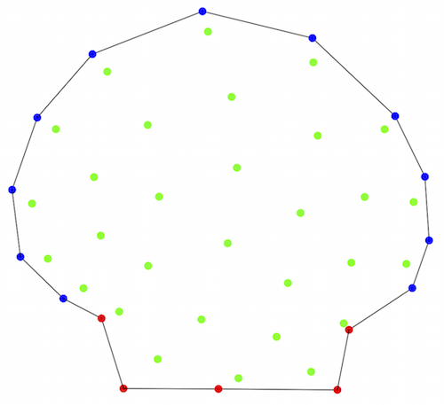

```r
data(scallops) ## dataset of scallop shells with semilandmarks
attributes(scallops)
scallops$curvslide ## the curve sliding matrix
head(scallops$surfslide) ## the surfaces sliding matrix
scallop.gpa = gpagen(A=scallops$coorddata,
                     curves=scallops$curvslide,
                     surfaces=scallops$surfslide) ## GPA-alignment
  scallop.gpa$coords ## 3D array of Procrustes coordinates
  scallop.gpa$Csize ## Vector of centroid sizes
```

With 3D data, the function plots the aligned specimens in an rgl window.

To make one these curve sliding matrices, you can use the interactive function `define.sliders`. Here we will run it using the first specimen, and hiding the surface sliding landmarks to make things easier to see

```r
define.sliders(scallops$coorddata[,,1],
               nsliders=11,
               surfsliders = scallops$surfslide) ## Interactive function in rgl window
```

The way this function works is to select the landmarks in a “before” “slide” “after” pattern, so defining between which landmarks the semilandmark will slide:

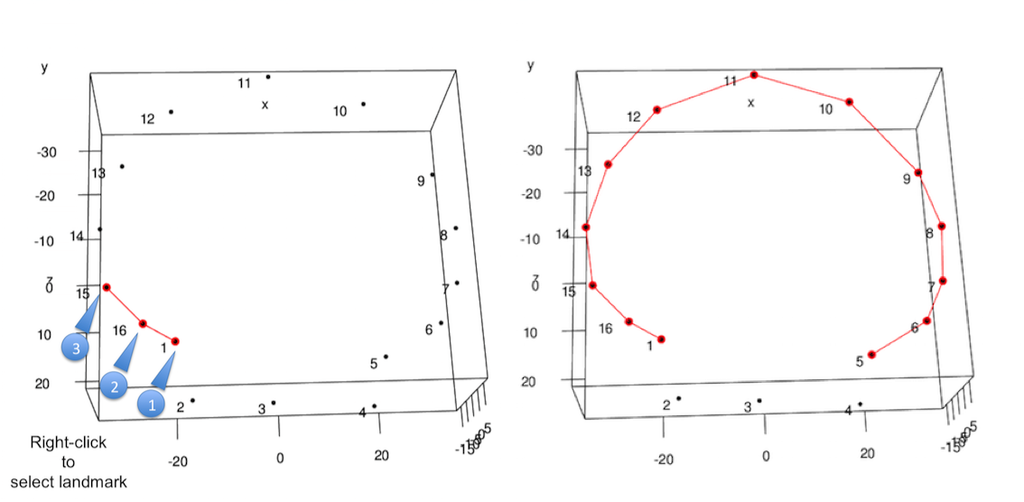

Left: In action. Right: Finished. And in the console will be printed:

```
semi-landmark 16 slides between landmarks 1 and 15
semi-landmark 15 slides between landmarks 16 and 14
semi-landmark 14 slides between landmarks 15 and 13
semi-landmark 13 slides between landmarks 14 and 12
semi-landmark 12 slides between landmarks 13 and 11
semi-landmark 11 slides between landmarks 12 and 10
semi-landmark 10 slides between landmarks 11 and 9
semi-landmark 9 slides between landmarks 10 and 8
semi-landmark 8 slides between landmarks 9 and 7
semi-landmark 7 slides between landmarks 8 and 6
semi-landmark 6 slides between landmarks 7 and 5
```

Once the above function has run, you will need to read in the outputted file for using in the GPA as follows

```r
curves <- as.matrix(read.csv("curveslide.csv", header=TRUE))
  ## as.matrix is necessary here to ascertain numeric
```

**For all subsequent analyses, the Procrustes coordinates (i.e., Y$coords) should be used**

## Generalized Procrustes Analysis with Bilateral Symmetry Analysis (`bilat.symmetry`)

If the data has bilateral symmetry, the first step is to perform a superimposition of the raw coordinate data taking into account the symmetry. This function also assesses the statistical differences in the symmetric data.

### Function:

```
bilat.symmetry(A, ind = NULL, side = NULL, replicate = NULL, object.sym = FALSE, land.pairs = NULL, data = NULL, iter = 999, seed = NULL, RRPP = TRUE)
```

### Arguments:

- *A* A 3D array (p x k x n) containing GPA-aligned coordinates for a set of specimens [for “object.sym=FALSE, A is of dimension (n x k x 2n)]
- *ind* A vector containing labels for each individual. For matching symmetry, the matched pairs receive the same label (replicates also receive the same label)
- *side* An optional vector (for matching symmetry) designating which object belongs to which ‘side-group’
- *replicate* An optional vector designating which objects belong to which group of replicates
- *object.sym* A logical value specifying whether the analysis should proceed based on object `symmetry =TRUE` or matching `symmetry =FALSE`
- *land.pairs* An optional matrix (for object symmetry) containing numbers for matched pairs of landmarks across the line of symmetry
- *data* A data frame for the function environment, see `geomorph.data.frame`. It is imperative that the variables “ind”, “side”, and “replicate” in the data frame match these names exactly
- *iter* Number of iterations for significance testing
- *seed* An optional argument for setting the seed for random permutations of the resampling procedure. If left NULL (the default), the exact same P-values will be found for repeated runs of the analysis (with the same number of iterations). If seed = “random”, a random seed will be used, and P-values will vary. One can also specify an integer for specific seed values, which might be of interest for advanced users
- *RRPP* A logical value indicating whether residual randomization should be used for significance testing

The function quantifies components of shape variation for a set of specimens as described by their patterns of symmetry and asymmetry. Here, shape variation is decomposed into variation among individuals, variation among sides (directional asymmetry), and variation due to an individual x side interaction (fluctuating symmetry). These components are then statistically evaluated using Procrustes ANOVA and Goodall’s F tests (i.e., an isotropic model of shape variation). Methods for both matching symmetry and object symmetry can be implemented. Matching symmetry is when each object contains mirrored pairs of structures (e.g., right and left hands) while object symmetry is when a single object is symmetric about a midline (e.g., right and left sides of human faces). Analytical and computational details concerning the analysis of symmetry in geometric morphometrics can be found in Mardia et al. (2000) and Klingenberg et al. (2002).

Analyses of symmetry for matched pairs of objects is implemented when `object.sym=FALSE`. Here, a 3D array [p x k x 2n] contains the landmark coordinates for all pairs of structures (2 structures for each of n specimens). Because the two sets of structures are on opposite sides, they represent mirror images, and one set must be reflected prior to the analysis to allow landmark correspondence. It is assumed that the user has done this prior to performing the symmetry analysis. Reflecting a set of specimens may be accomplished by multiplying one coordinate dimension by ‘-1’ for these structures (either the x-, the y-, or the z-dimension). A vector containing information on individuals and sides must also be supplied. Replicates of each specimen may also be included in the dataset, and when specified will be used as measurement error (see Klingenberg and McIntyre 1998).

Analyses of object symmetry is implemented when `object.sym=TRUE`. Here, a 3D array [p x k x n] contains the landmark coordinates for all n specimens. To obtain information about asymmetry, the function generates a second set of objects by reflecting them about one of their coordinate axes. The landmarks across the line of symmetry are then relabeled to obtain landmark correspondence. The user must supply a list of landmark pairs. A vector containing information on individuals must also be supplied. Replicates of each specimen may also be included in the dataset, and when specified will be used as measurement error.

### Notes for geomorph 3.0

Compared to older versions of *geomorph*, some results can be expected to be slightly different. Starting with geomorph 3.0, results use only type I sums of squares (SS) with either full randomization of raw shape values or RRPP (preferred with nested terms) for analysis of variance (ANOVA). Older versions used a combination of parametric and non-parametric results, as well as a combination of type I and type III SS. While analytical conclusions should be consistent (i.e., “significance” of effects is the same), these updates maintain consistency in analytical philosophy. This change will require longer computation time for large datasets, but the trade-off allows users to have more flexibility and eliminates combining disparate analytical philosophies.

Note also that significance of terms in the model are found by comparing F-values for each term to those obtained via permutation. F-ratios and df are not strictly necessary (a ratio of SS would suffice), but they are reported as is standard for anova tables. Additionally, users will notice that the df reported are based on the number of observations rather than a combination of objects * coordinates * dimensions, as is sometimes found in morphometric studies of symmetry. However, this change has no effect on hypothesis testing, as only SS vary among permutations (df, coordinates, and dimensions are constants).

### Example of matching symmetry

```r
data(mosquito)
gdf <- geomorph.data.frame(wingshape = mosquito$wingshape,
      ind=mosquito$ind, side=mosquito$side,
      replicate=mosquito$replicate) ## make geomorph.data.frame
mosquito.sym <- bilat.symmetry(A = wingshape, ind = ind, side = side,
                replicate = replicate, object.sym = FALSE, RRPP = TRUE,
                iter = 499, data = gdf) ## perform matching symmetry GPA
summary(mosquito.sym)
```

```
Call:
bilat.symmetry(A = wingshape, ind = ind, side = side, replicate = replicate,
    object.sym = FALSE, data = gdf, iter = 499, RRPP = TRUE)


Symmetry (data) type: Matching

Type I (Sequential) Sums of Squares and Cross-products
Randomized Residual Permutation Procedure Used
500 Permutations

Shape ANOVA
                   Df       SS        MS     Rsq      F       Z Pr(>F)
ind                 9 0.104888 0.0116542 0.45533 2.6901 1.34269  0.062 .
side                1 0.003221 0.0032209 0.01398 0.7435 0.60403  0.674
ind:side            9 0.038990 0.0043323 0.16926 1.0407 0.69384  0.954
ind:side:replicate 20 0.083259 0.0041629 0.36143
---
Signif. codes:  0 '***' 0.001 '**' 0.01 '*' 0.05 '.' 0.1 ' ' 1


Centroid Size ANOVA
                   Df         SS         MS     Rsq      F       Z Pr(>F)
ind                 9 4.1497e-09 4.6107e-10 0.18555 0.5965 0.28447  0.898
side                1 3.4740e-10 3.4738e-10 0.01553 0.4494 0.18543  0.530
ind:side            9 6.9569e-09 7.7299e-10 0.31108 1.4170 0.72586  0.566
ind:side:replicate 20 1.0910e-08 5.4549e-10 0.48784
```

Function returns the ANOVA table for analysis of symmetry and a graph showing the shape deformations relating to the symmetric and asymmetric components of shape. When `verbose=TRUE`, the function returns the symmetric component of shape variation (`$symm.shape`) and the asymmetric component of shape variation (`$asymm.shape`), to be used in subsequent analyses like Procrustes coordinates.

### Example of object symmetry

```
Call:
bilat.symmetry(A = shape, ind = ind, object.sym = TRUE, land.pairs = scallops$land.pairs,
    data = gdf, iter = 499, RRPP = TRUE)


Symmetry (data) type: Object

Type I (Sequential) Sums of Squares and Cross-products
Randomized Residual Permutation Procedure Used
500 Permutations

Shape ANOVA
         Df       SS        MS     Rsq       F       Z Pr(>F)
ind       4 0.064030 0.0160075 0.64431  9.8348 0.59476  0.978
side      1 0.028838 0.0288375 0.29018 17.7173 2.07959  0.064 .
ind:side  4 0.006511 0.0016276 0.06551
---
Signif. codes:  0 '***' 0.001 '**' 0.01 '*' 0.05 '.' 0.1 ' ' 1
```

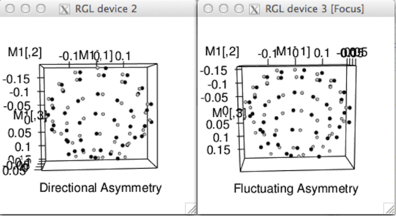

```r
data(scallops)
gdf <- geomorph.data.frame(shape = scallops$coorddata, ind=scallops$ind)
scallop.sym <- bilat.symmetry(A = shape, ind = ind, object.sym = TRUE,
               land.pairs=scallops$land.pairs, data = gdf, RRPP = TRUE,
               iter = 499) ## perform object symmetry GPA
summary(scallop.sym)
```

# Data Analysis

After the data have been superimposed with `gpagen` or `bilat.symmetry`, the Procrustes coordinates can be used in many statistical analyses, ordination methods and visualization methods.

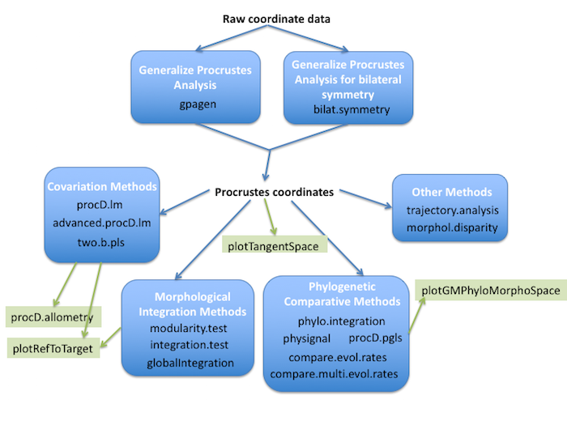

**Figure 3** Overview of some of the analysis (blue) and visualization (green) functions in *geomorph*.

# References

Adams, D. C., F. J. Rohlf, and D. E. Slice. 2004. Geometric morphometrics: ten years of progress following the ‘revolution’. It. J. Zool. 71:5-16.

Adams, D. C., F. J. Rohlf, and D. E. Slice. 2013. A field comes of age: Geometric morphometrics in the 21st century. Hystrix.24:7-14.

Berns, C.M., and Adams, D.C. 2010. Bill shape and sexual shape dimorphism between two species of temperate hummingbirds: Archilochus alexandri (black-chinned hummingbirds) and Archilochus colubris (ruby-throated hummingbirds). The Auk. 127:626-635.

Bookstein, F. L. 1991. Morphometric tools for landmark data: Geometry and Biology. Cambridge Univ. Press, New York.

Bookstein, F. L. 1997. Landmark methods for forms without landmarks: morphometrics of group differences in outline shape. 1:225-243.

Dryden, I. L., and K. V. Mardia. 1993. Multivariate shape analysis. Sankhya 55:460-480.

Gower, J. C. 1975. Generalized Procrustes analysis. Psychometrika 40:33-51.

Gunz, P., P. Mitteroecker, and F. L. Bookstein. 2005. semilandmarks in three dimensions. Pp. 73-98 in D. E. Slice, ed. Modern morphometrics in physical anthropology. Klewer Academic/Plenum, New York.

Kendall, D. G. 1984. Shape-manifolds, Procrustean metrics and complex projective spaces. Bulletin of the London Mathematical Society 16:81-121.

Klingenberg, C.P., M. Barluenga, and A. Meyer. 2002. Shape analysis of symmetric structures: quantifying variation among individuals and asymmetry. Evolution. 56:1909-1920.

Klingenberg, C.P. and G.S. McIntyre. 1998. Quantitative genetics of geometric shape in the mouse mandible. Evolution. 55:2342-2352.

Mardia, K.V., F.L. Bookstein, and I.J. Moreton. 2000. Statistical assessment of bilateral symmetry of shapes. Biometrika. 87:285-300.

Mitteroecker, P., and P. Gunz. 2009. Advances in geometric morphometrics. Evol. Biol. 36:235-247.

Rohlf, F. J., and D. E. Slice. 1990. Extensions of the Procrustes method for the optimal superimposition of landmarks. Syst. Zool. 39:40-59.

Rohlf, F. J., and L. F. Marcus. 1993. A revolution in morphometrics. Trends Ecol. Evol. 8:129-132.

Rohlf, F. J. 1999. Shape statistics: Procrustes superimpositions and tangent spaces. Journal of Classification 16:197-223.

Rohlf, F. J. 2010. tpsRelw: Relative warps analysis. Version 1.49. Department of Ecology and Evolution, State University of New York at Stony Brook, Stony Brook, NY.

Zelditch, M. L., D. L. Swiderski, H. D. Sheets, and W. L. Fink. 2012. Geometric morphometrics for biologists: a primer. 2nd edition. Elsevier/Academic Press, Amsterdam.